# sfnetworks_viz

## Hackathon on `sfnetworks` visualization

This is the issue for this hackathon: https://github.com/luukvdmeer/sfnetworks/issues/7

We started this hackathon with [Pedro Pérez](https://github.com/perezp44) and [John Coene](https://github.com/JohnCoene) by brainstorming on what would be good ways of visualizing `sfnetwork` objects.

In honor of time, we decided to look into how to use the `sfnetwork` class with [`ggraph`](https://ggraph.data-imaginist.com/index.html).

## `ggraph` mapping

This package is meant to support a grammar of graphics for relational data. It works perfectly with `tbl_graph` objects and since `sfnetworks` subclasses `tbl_graph` we thought it would be not so difficult to already use it inside `ggraph()`.

### Some background on how `ggraph` works:

- [Layouts](https://ggraph.data-imaginist.com/articles/Layouts.html): Defines how nodes are placed on the plot, so where to put each node.
- [Nodes](https://ggraph.data-imaginist.com/articles/Nodes.html): how the nodes are represented.
- [Edges](https://ggraph.data-imaginist.com/articles/Edges.html): how the edges are represented.

### What we found out:

- We can pass X and Y coordinates to the layout function to place the nodes on the plot. As `sfnetworks` has its nodes as an `sf` object with a `POINT` geometry, we can retrieve those X and Y coordinates easily.
- Nodes will take their placing from the layout, and `geom_node_*()` will basically be in charge of figuring out how it should be represented. Usually we would go for `geom_node_point()` on a “spatial” representation of a network.
- Edges can have different representations between their from and to edges which are already supported when an appropriate layout is established. But, when we want to plot the edges to their faithful location in space, we need to think of a new `geom_edge_*()` function.

### Let’s go to the code

We first call the workforce (packages) and save our sample data on an object:

```
library(ggraph)
library(ggplot2)
library(tidygraph)
library(sfnetworks)
library(sf)

(roxel_net = as_sfnetwork(roxel, directed = F))

## # An sfnetwork with 701 nodes and 851 edges
## #
## # CRS:  EPSG:4326
## #
## # An undirected multigraph with 14 components with spatially explicit edges
## #
## # Node Data:     701 x 1 (active)
## # Geometry type: POINT
## # Dimension:     XY
## # Bounding box:  xmin: 7.522622 ymin: 51.94151 xmax: 7.546705 ymax: 51.9612
##              geometry
##           <POINT [°]>
## 1 (7.533722 51.95556)
## 2 (7.533461 51.95576)
## 3 (7.532442 51.95422)
## 4  (7.53209 51.95328)
## 5 (7.532709 51.95209)
## 6 (7.532869 51.95257)
## # ... with 695 more rows
## #
## # Edge Data:     851 x 5
## # Geometry type: LINESTRING
## # Dimension:     XY
## # Bounding box:  xmin: 7.522594 ymin: 51.94151 xmax: 7.546705 ymax: 51.9612
##    from    to name           type                                       geometry
##   <int> <int> <fct>          <fct>                              <LINESTRING [°]>
## 1     1     2 Havixbecker S~ residen~     (7.533722 51.95556, 7.533461 51.95576)
## 2     3     4 Pienersallee   seconda~ (7.532442 51.95422, 7.53236 51.95377, 7.5~
## 3     5     6 Schulte-Bernd~ residen~ (7.532709 51.95209, 7.532823 51.95239, 7.~
## # ... with 848 more rows
```

Since `sfnetwork` subclasses `tbl_graph` we can already put it into `ggraph`, but the chosen layout for the nodes might not be the most appropriate:

```
roxel_net %>%
  as_tbl_graph() %>%
  ggraph() +
  geom_node_point() +
  geom_edge_link()

## Using `stress` as default layout
```

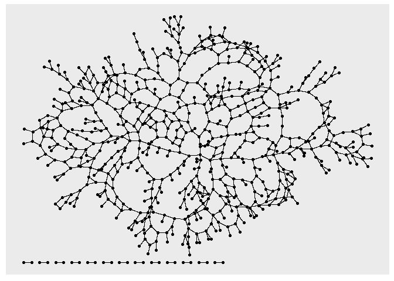

So, let’s create a layout function! As explained before, we can retrieve the X and Y coordinates of the nodes, since they are an `sf` object with `POINT` geometry:

```
layout_sf <- function(graph){
  graph %>%
    activate("nodes") %>%
    mutate(
      x = sf::st_coordinates(.)[,"X"],
      y = sf::st_coordinates(.)[,"Y"]
    )
}
```

We can now use this layout inside `ggraph`:

```
roxel_net %>%
  ggraph(layout = layout_sf) +
  geom_node_point()
```

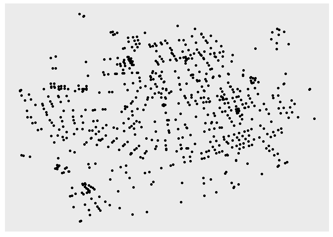

You will see some spatial distortion up there and that will be due to the lat/long nature of the `sfnetwork` CRS. This remains for now an issue to look into…

But, for now let’s get going! We can now plot nodes on their geographical space! And than add any edge representation between them:

```
roxel_net %>%
  # st_transform(3035) %>%
  ggraph(layout = layout_sf) +
  geom_node_point() +
  geom_edge_arc()
```

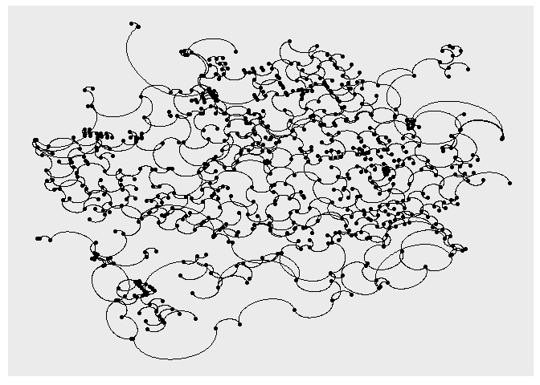

But, we also want to be able to plot edges in their geographical space. So for this we propose creating a new `geom_edge_*()` function that builds on top of `geom_sf()` in ggplot2 which handles `sf` objects.

First we fetch the edges:

```
get_sf_edges <- function(){
  function(layout) {
    attr(layout, "graph") %>%
      as_sfnetwork(directed = FALSE) %>%
      activate("edges") %>%
      sf::st_as_sf()
  }
}
```

And then we can create `geom_edge_sf()`:

```
geom_edge_sf = function (mapping = NULL, data = get_sf_edges(), ...){
  geom_sf(data = data, mapping = mapping, ...)
}
```

And we can easily add it to our plot!

```
roxel_net %>%
  ggraph(layout = layout_sf) +
  geom_node_point() +
  geom_edge_sf(aes(color = type))
```

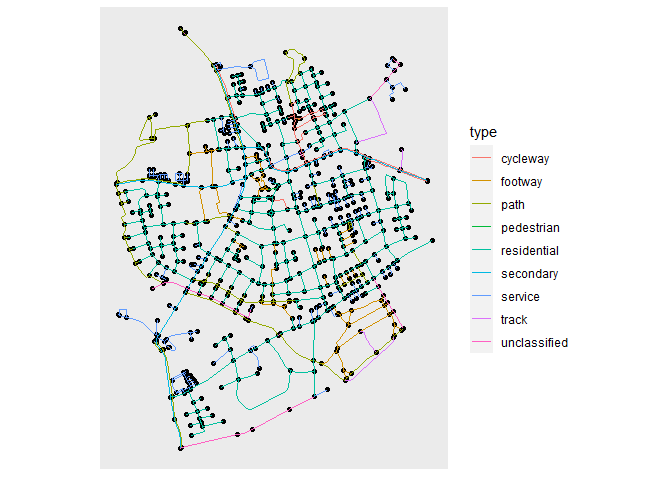

And there we have it! Note how the distortion get’s handle by `geom_sf()` very nicely!

### (Recap of) open issues:

- We still need to think how to handle lat/long data on the layout_sf function, since unprojected networks can appear distorted when plotted.

### Other visualization opportunities:

- explore 3D representation, maybe with `rayshader`
  - this can take a look into st_zm coordinates
- maybe look into interactive plotting: `mapview`

## Summary:

- A `layout_sf()` function can be implemented to plot the nodes in their geographical space.
- A `geom_edge_sf()` function can be implemented to plot edges on their geographical space and still access their columns to map aesthetics.

The ultimate goal would be to create a pull request to `ggraph`!